# A web scraper tutorial using R packages `httr` and `rvest`

Luis M. Avila

10/30/2017

I this tutorial we will learn:

- How to get (download) a website using the `httr` package
- How to parse html using the `rvest` package
- How to use html forms with the `httr` package
- Transforming out parsed data into a tidy table

For a web scraping example I will use a table of exchange rates (peruvian soles to US dollars) from Peru’s tax agency SUNAT. Today (someday of Oct 2017) that page looked like this:

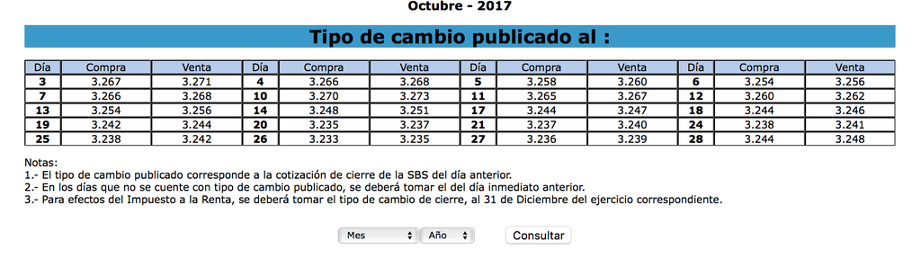

### 1. Loading the libraries and downloading a website

```r
 library(httr)  # will be use to make HTML GET and POST requests
 library(rvest) # will be used to parse HTML
 library(tidyr) #will be used to remove NA


 url <- 'http://www.sunat.gob.pe/cl-at-ittipcam/tcS01Alias'

 website1 <- GET(url) #it also gets the cookies that httr will mantain
#cookies(r)
 print(content(website1))
```

```
## {xml_document}
## <html>
## [1] <head>\n<meta http-equiv="Pragma" content="no-cache">\n<meta http-eq ...
## [2] <script language="JavaScript">\r\n\r\nfunction CheckSubmit(){\r\n    ...
## [3] <link href="/a/css/estilos2_0.css" type="text/css" rel="stylesheet">\n
## [4] <script language="JavaScript" src="/a/js/js.js"></script>
## [5] <body background="#ffffff">\r\n\r\n<form method="POST" action="tcS01 ...
```

### 2. Getting information from a website with `html_nodes` from the `rvest` package

We get the webpage title and tables with `html_nodes` and labels such as `h3` which was used for the title of the website and `table` used for the tables.

```r
  titles <- html_nodes(content(website1), "h3")
  print(html_text(titles)[[1]])
```

```
## [1] "Noviembre - 2017"
```

```r
  tbls <- html_nodes(content(website1), "table")
  print(length(tbls))
```

```
## [1] 6
```

We can see that there are 6 tables. But through trial and error I find that my table of interest is table 2.

```r
  tbl2<-html_table(tbls[[2]],fill=TRUE)
  print(tbl2)
```

```
##    X1     X2    X3  X4     X5    X6   X7     X8    X9  X10    X11   X12
## 1 Día Compra Venta Día Compra Venta  Día Compra Venta  Día Compra Venta
## 2   1  3.246 3.250   3  3.242 3.244 <NA>   <NA>  <NA> <NA>   <NA>  <NA>
```

## 3. Downloading data from past months using html forms

If we examine the source code of the website we will find that it uses html forms to pass month and year information to show past reports. The form method used is `POST`. We will prepare a query with the fields of the form and submit that info with `POST` function from `httr`.

This page we are using is in spanish and the fields of the form are called “anho” (a aproximation of the spanish word for year) and “mes” (spanish for month). We will request data for October (10) of 2017. Again, we web html as reponse.

```r
query <- list('mes'="10",
    'anho'="2017"
    )
website2<-POST(url, body = query,encode = "form")
print(content(website2))
```

```
## {xml_document}
## <html>
## [1] <head>\n<meta http-equiv="Pragma" content="no-cache">\n<meta http-eq ...
## [2] <script language="JavaScript">\r\n\r\nfunction CheckSubmit(){\r\n    ...
## [3] <link href="/a/css/estilos2_0.css" type="text/css" rel="stylesheet">\n
## [4] <script language="JavaScript" src="/a/js/js.js"></script>
## [5] <body background="#ffffff">\r\n\r\n<form method="POST" action="tcS01 ...
## [6] <html><script id="f5_cspm">(function(){var f5_cspm={f5_p:'GLODMKKIHL ...
```

```r
titles <- html_nodes(content(website2), "h3")
print(html_text(titles)[[1]])
```

```
## [1] "Octubre - 2017"
```

And we can get the title of the page and our table of interest for that month.

```r
tbls <- html_nodes(content(website2), "table")
print(length(tbls))
```

```
## [1] 6
```

```r
tbl2<-html_table(tbls[[2]],fill=TRUE)
print(tbl2)
```

```
##    X1     X2    X3   X4     X5    X6   X7     X8    X9  X10    X11   X12
## 1 Día Compra Venta  Día Compra Venta  Día Compra Venta  Día Compra Venta
## 2   3  3.267 3.271    4  3.266 3.268    5  3.258 3.260    6  3.254 3.256
## 3   7  3.266 3.268   10  3.270 3.273   11  3.265 3.267   12  3.260 3.262
## 4  13  3.254 3.256   14  3.248 3.251   17  3.244 3.247   18  3.244 3.246
## 5  19  3.242 3.244   20  3.235 3.237   21  3.237 3.240   24  3.238 3.241
## 6  25  3.238 3.242   26  3.233 3.235   27  3.236 3.239   28  3.244 3.248
## 7  31  3.247 3.253 <NA>   <NA>  <NA> <NA>   <NA>  <NA> <NA>   <NA>  <NA>
```

## 4. Reformatting the data into a tidy data.frame

```r
  num.cols<-dim(tbl2)[2]
  num.rows<-dim(tbl2)[1]
  print(dim(tbl2))
```

```
## [1]  7 12
```

We already have the number of rows and columns and we used them to create vectors that we then integrate into a data.frame

```r
  dia<-c() #will store day numbers
  compra<-c() # will store purchase price
  venta<-c()  # will store sell price

  for(i in 2:num.rows){
     for(j in 1:(num.cols/3)){
        dia<-c(dia,as.numeric(tbl2[i,(j-1)*3+1]))
        compra<-c(compra,as.numeric(tbl2[i,(j-1)*3+2]))
        venta<-c(venta,as.numeric(tbl2[i,(j-1)*3+3]))
     }
  }

  pen.oct.2017<-data.frame(dia,compra,venta)
  pen.oct.2017<- pen.oct.2017 %>% drop_na() #dropping NA (not available) values
  print(pen.oct.2017,row.names = FALSE)
```

```
##  dia compra venta
##    3  3.267 3.271
##    4  3.266 3.268
##    5  3.258 3.260
##    6  3.254 3.256
##    7  3.266 3.268
##   10  3.270 3.273
##   11  3.265 3.267
##   12  3.260 3.262
##   13  3.254 3.256
##   14  3.248 3.251
##   17  3.244 3.247
##   18  3.244 3.246
##   19  3.242 3.244
##   20  3.235 3.237
##   21  3.237 3.240
##   24  3.238 3.241
##   25  3.238 3.242
##   26  3.233 3.235
##   27  3.236 3.239
##   28  3.244 3.248
##   31  3.247 3.253
```